# Impacto del Estilo de Vida en el Rendimiento Académico: Análisis Descriptivo e Intra-Sujeto

S1 Métodos Estadísticos Avanzados — Unidad 2

Author

Juan Nicolás Patiño Rodríguez

Published

September 16, 2026

# 1 Contexto y objetivo

**Tema seleccionado:** Tema 3 de la guía de actividades — *“¿Influye nuestro estilo de vida en el rendimiento académico?”*

**Pregunta de investigación:** ¿Cómo se relacionan el consumo de alcohol los fines de semana (`Walc`) y la zona de residencia (`address`) con el rendimiento académico (`G3`) y las inasistencias (`absences`) de estudiantes que cursan simultáneamente Matemáticas y Lengua Portuguesa, y qué tan variable es ese comportamiento entre géneros?

*En palabras simples:* queremos saber si los estudiantes que consumen más alcohol los fines de semana, o que viven en zona rural, tienden a tener notas o inasistencias distintas, y si eso cambia entre hombres y mujeres.

**Objetivos:**

- **Describir** el comportamiento de las calificaciones finales y las inasistencias en ambas asignaturas, e **identificar** los valores atípicos (muy alejados del resto) con un criterio estadístico formal, la regla del rango intercuartílico.
- **Comparar** las notas entre estudiantes urbanos y rurales, y entre niveles de consumo de alcohol y sexo, para ver si hay diferencias claras.
- **Analizar** qué tan fuerte es la relación entre las notas de las dos asignaturas y entre el alcohol y las notas.

Este es un análisis **descriptivo**: muestra cómo se asocian las variables, pero no permite afirmar que una cause a la otra.

# 2 Datos

**Fuente:** *Student Performance Data Set* (UCI Machine Learning Repository), publicado originalmente por Cortez & Silva (2008) — ver Referencias. Contiene registros de estudiantes de dos escuelas secundarias portuguesas en las asignaturas de Matemáticas y Lengua Portuguesa.

**Tamaño muestral:** el conjunto de Matemáticas y el de Lengua Portuguesa se cruzaron usando **13 llaves demográficas compartidas** (edad, sexo, dirección, tamaño y estado de convivencia familiar, educación y profesión de los padres, motivo de elección de escuela, acceso a guardería previa e internet), siguiendo el método `student-merge.R` documentado por los propios autores del dataset. Este cruce produjo una cohorte común de **N = 382 estudiantes** que aparecen en ambos conjuntos.

Conviene ser precisos sobre el alcance de este método: las 13 llaves forman un **perfil demográfico compartido**, no un identificador único verificado. Dos estudiantes distintos con exactamente el mismo perfil (misma edad, sexo, dirección, educación de los padres, etc.) se fusionarían igual, sin ser necesariamente la misma persona. Es la técnica estándar que acompaña al dataset y su uso está justificado, pero se reporta como lo que es: una coincidencia por atributos compartidos, no una identificación absoluta.

**Variables usadas:**

| Variable | Tipo | Escala o uso |
| --- | --- | --- |
| `G3.mat`, `G3.por` | Cuantitativa | Nota final, de 0 a 20 |
| `absences.mat`, `absences.por` | Cuantitativa | Número de inasistencias |
| `age` | Cuantitativa | Edad en años |
| `Walc` | Categórica ordinal | Alcohol en el fin de semana, de 1 (muy bajo) a 5 (muy alto) |
| `sex` | Categórica | F (mujer) o M (hombre) |
| `address` | Categórica | U (urbana) o R (rural) |
| `traveltime` | Categórica ordinal | Tiempo de viaje al colegio: 1 (menos de 15 min), 2 (15 a 30 min), 3 (30 a 60 min), 4 (más de 60 min) |

Dos aclaraciones sobre los datos. Primero, `traveltime` es un **código ordinal**, no horas; se toma del cuestionario de Matemáticas y aquí se usa el porcentaje de estudiantes con código 3 o 4 (30 minutos o más). Segundo, 39 estudiantes tienen nota final 0 en Matemáticas (y 5 en Portugués), todos con 0 inasistencias; este detalle se retoma en Resultados porque afecta algunas comparaciones.

# 3 Metodología

**NoteNota sobre la reproducibilidad**

Todo el análisis se ejecuta con un flujo modular en R: los datos se leen desde una base SQLite mediante una clase que sigue un contrato común de proveedor de datos, las funciones validan sus entradas antes de calcular y la semilla aleatoria está fija (`set.seed(2026)`). Así, cualquier persona puede repetir el informe y obtener las mismas cifras.

**Diseño intra-sujeto (within-subject):** mirar el rendimiento en un solo curso deja fuera información valiosa. Al observar el mismo perfil de estudiante en dos áreas distintas —lógico-matemática (`G3.mat`) y verbal-lingüística (`G3.por`)— los datos de colegio y de familia coinciden en ambas materias, lo que hace la comparación más justa. Esto se dice con la salvedad señalada en la sección anterior: el cruce es por perfil, no por identificador único.

**Criterio formal de atípicos:** un valor atípico es un valor muy alejado del resto. Para detectarlos se usa la regla de Tukey, una forma estándar basada en el rango intercuartílico (IQR): un valor es atípico si cae por debajo de $Q_1 - 1.5 \times \text{IQR}$ o por encima de $Q_3 + 1.5 \times \text{IQR}$. Está implementada en `app/pipelines/summary_stats.R::iqr_outliers()` y reemplaza cualquier afirmación puramente narrativa de “valores extremos” por un conteo y un límite numérico verificable (ver Resultados).

**Cómo se comparan los grupos:**

- **Alcohol en tres niveles.** En el nivel 5 hay muy pocos estudiantes (solo 4 mujeres frente a 23 hombres), así que los promedios de esa celda serían poco confiables. Por eso se agrupa en Bajo (1–2), Moderado (3) y Alto (4–5).
- **Barras de error.** Las figuras muestran el promedio de cada grupo y su error estándar (SE), que indica cuánto puede variar ese promedio de una muestra a otra. Solo se **describen**; no se usan como prueba de significancia.
- **Correlaciones.** Se reporta la correlación de Pearson (*r*, de −1 a 1) y, como el alcohol es una escala ordenada, también la de Spearman.
- **Diferencia de promedios.** Se calcula con la prueba de Welch y se muestra su intervalo de confianza del 95% (IC 95%): el rango de valores razonables para la diferencia real. Si el intervalo incluye el 0, la diferencia es incierta.

# 4 Desarrollo

## 4.1 Análisis Descriptivo Cuantitativo

Tabla 1. Estadísticas descriptivas de variables cuantitativas clave

| Variable | N Total | Datos Faltantes | Media | Mediana | Moda (Det) | Mínimo | Máximo | Desv. Estándar | Varianza | Rango |
| --- | --- | --- | --- | --- | --- | --- | --- | --- | --- | --- |
| age | 382 | 0 | 16.586 | 17 | 16 | 15 | 22 | 1.173 | 1.377 | 7 |
| absences.mat | 382 | 0 | 5.319 | 3 | 0 | 0 | 75 | 7.625 | 58.144 | 75 |
| absences.por | 382 | 0 | 3.673 | 2 | 0 | 0 | 32 | 4.906 | 24.068 | 32 |
| G3.mat | 382 | 0 | 10.387 | 11 | 10 | 0 | 20 | 4.687 | 21.970 | 20 |
| G3.por | 382 | 0 | 12.516 | 13 | 13 | 0 | 19 | 2.945 | 8.676 | 19 |

## 4.2 Análisis Descriptivo Cualitativo

Tabla 2. Distribución de frecuencias para factores cualitativos de la cohorte

| Variable | Categoría / Valor | Frecuencia Absoluta | Proporción |
| --- | --- | --- | --- |
| sex | F | 198 | 0.5183 |
| sex | M | 184 | 0.4817 |
| address | R | 81 | 0.2120 |
| address | U | 301 | 0.7880 |
| internet | no | 58 | 0.1518 |
| internet | yes | 324 | 0.8482 |
| Walc.mat | 1 | 146 | 0.3822 |
| Walc.mat | 2 | 85 | 0.2225 |
| Walc.mat | 3 | 76 | 0.1990 |
| Walc.mat | 4 | 48 | 0.1257 |
| Walc.mat | 5 | 27 | 0.0707 |

**Interpretación:**

- **Sexo (`sex`):** la cohorte está compuesta por 51.83% de mujeres y 48.17% de hombres: una distribución balanceada que permite comparar por género sin que un grupo domine la muestra.
- **Zona de residencia (`address`):** 78.8% de los estudiantes reside en zona urbana frente a 21.2% en zona rural. Los grupos son de tamaños muy distintos, por eso en Resultados se comparan con intervalos de confianza.
- **Consumo de alcohol los fines de semana (`Walc.mat`):** el 38.22% reporta consumo “muy bajo” (nivel 1), y el 19.64% se ubica en los niveles 4 y 5. Es una minoría, pero lo bastante grande como para evaluar su relación con el rendimiento.
- **Conectividad a internet (`internet`):** el 84.82% de la cohorte tiene acceso a internet en casa; una minoría de 15.18% no lo tiene.

# 5 Resultados

## 5.1 Notas entre asignaturas y consumo de alcohol

Para ver si las notas de Matemáticas y Portugués van de la mano, y dónde se ubican los estudiantes según su consumo de alcohol, se hizo un gráfico de dispersión con un pequeño desplazamiento aleatorio (jitter) para que los puntos no se tapen entre sí:

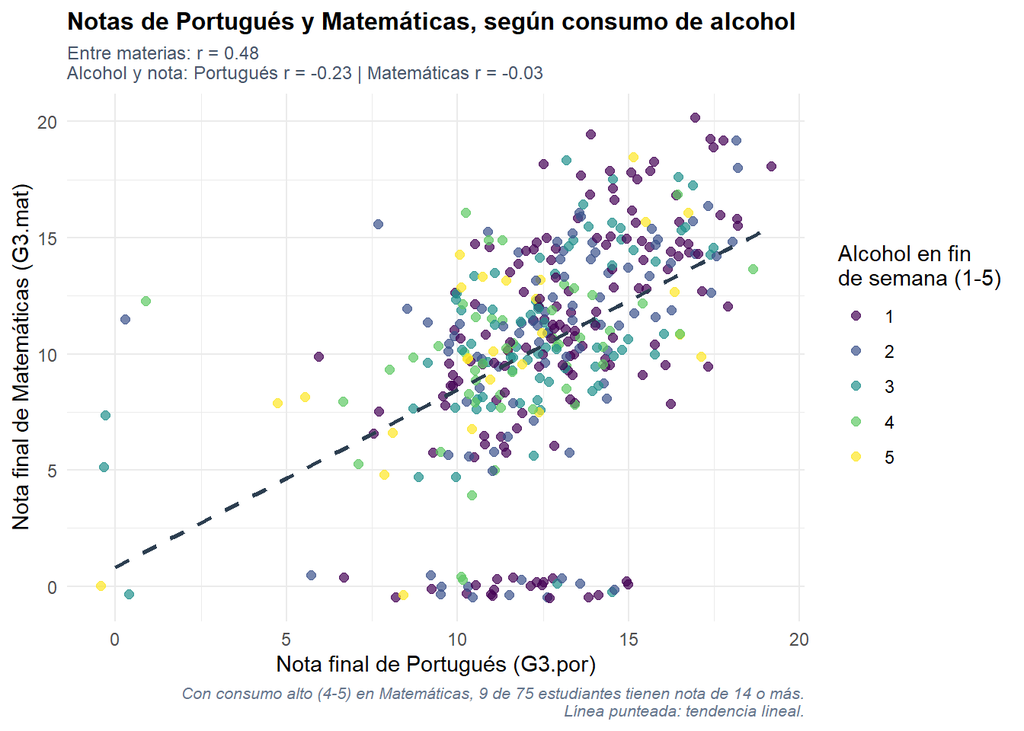

Figura 1. Notas de Matemáticas y Portugués según alcohol

**Interpretación:**

- **Entre materias:** la correlación es moderada y positiva (*r* = 0.48; Spearman = 0.55). Quien obtiene buenas notas en una asignatura suele obtenerlas en la otra, aunque con mucha variación entre estudiantes.
- **Alcohol y nota en Portugués:** la relación es débil pero distinta de cero (*r* = -0.23; Spearman = -0.21, *p* < 0.001). El alcohol se asocia con apenas cerca del 5% de la variación de la nota (*r*²).
- **Alcohol y nota en Matemáticas:** prácticamente nula (*r* = -0.03; Spearman = -0.08, *p* = 0.122).
- **Consumo alto (niveles 4 y 5):** en Matemáticas, 9 de 75 estudiantes (12%) tienen nota de 14 o más; en Portugués, 15 de 76 (20%). Es decir, un consumo alto convive con notas altas: el alcohol, por sí solo, dice poco sobre la nota de un estudiante.

## 5.2 Alcohol, sexo y notas

Para ver si la relación entre alcohol y notas cambia entre hombres y mujeres, se calculó el promedio de cada grupo (sexo por nivel de alcohol), con su error estándar:

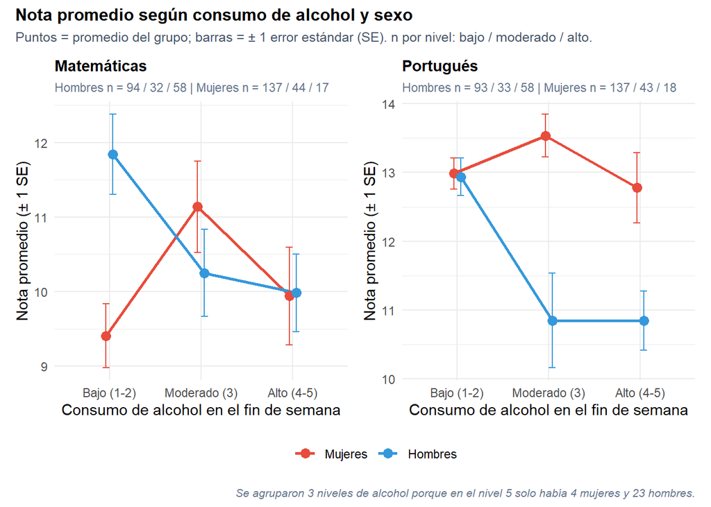

Figura 2. Nota promedio según alcohol y sexo (± 1 SE)

Tabla 3. Nota promedio (error estándar) y tamaño del grupo

| Asignatura | Sexo | Bajo (1-2) | Moderado (3) | Alto (4-5) |
| --- | --- | --- | --- | --- |
| Portugués | Hombres | 12.94 (SE 0.27), n = 93 | 10.85 (SE 0.69), n = 33 | 10.84 (SE 0.43), n = 58 |
| Portugués | Mujeres | 12.99 (SE 0.23), n = 137 | 13.53 (SE 0.31), n = 43 | 12.78 (SE 0.51), n = 18 |
| Matemáticas | Hombres | 11.84 (SE 0.54), n = 94 | 10.25 (SE 0.58), n = 32 | 9.98 (SE 0.52), n = 58 |
| Matemáticas | Mujeres | 9.41 (SE 0.43), n = 137 | 11.14 (SE 0.61), n = 44 | 9.94 (SE 0.66), n = 17 |

**Interpretación:**

- **Portugués:** con consumo bajo, hombres y mujeres promedian casi lo mismo (12.9 y 13.0). En los hombres el promedio baja a 10.8 en consumo moderado y se queda ahí en consumo alto (10.8): es un escalón, no una caída continua. En las mujeres el promedio se mantiene cerca de 13 (12.8 en consumo alto).
- **Matemáticas:** los hombres también bajan (11.8 → 10.0), pero las mujeres no siguen un patrón claro (9.4, 11.1 y 9.9); en consumo bajo ellas promedian menos que los hombres, a diferencia de Portugués, donde ambos promedian casi lo mismo.
- **Cautela:** solo hay 18 mujeres con consumo alto en Portugués (17 en Matemáticas), y 91% de las mujeres están en consumo bajo o moderado. Con grupos tan pequeños los promedios varían mucho, y varias barras de error se traslapan; por eso se describe el patrón sin declarar diferencias “significativas”.

## 5.3 Zona urbana y zona rural

Se comparan las notas según la zona de residencia (`address`: “U” urbana, “R” rural):

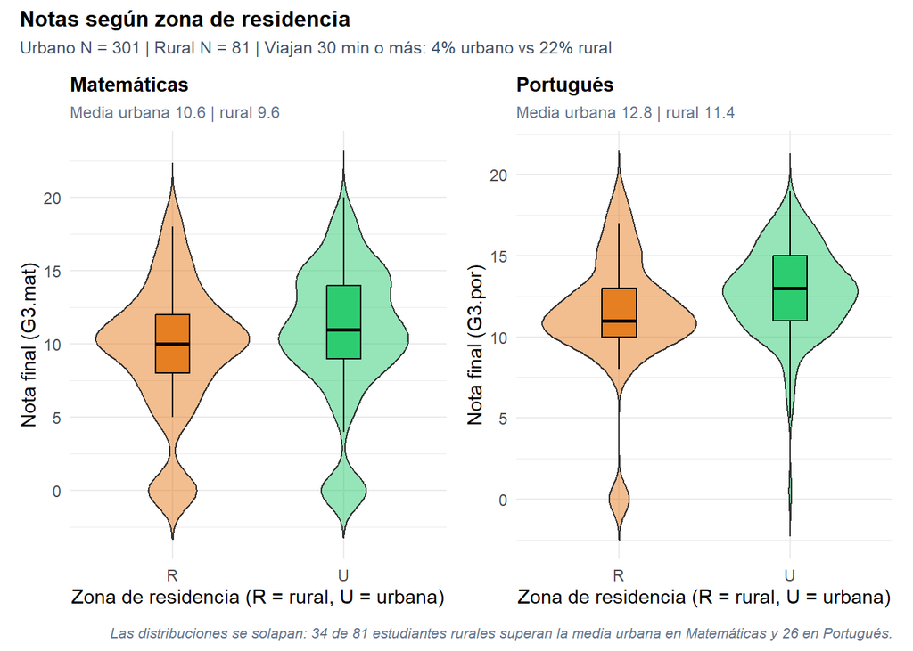

Figura 3. Distribuciones de notas finales por zona de residencia

Tabla 4. Diferencia de notas promedio entre zona rural y urbana

| Asignatura | Media urbana | Media rural | Diferencia (rural − urbano) | IC 95% | p (Welch) |
| --- | --- | --- | --- | --- | --- |
| Matemáticas | 10.61 | 9.56 | -1.06 | [-2.19; 0.08] | 0.069 |
| Portugués | 12.80 | 11.44 | -1.36 | [-2.21; -0.51] | 0.002 |

**Interpretación:**

- **Portugués:** los estudiantes rurales promedian 1.36 puntos menos, y el intervalo de confianza no incluye el 0: la diferencia es clara.
- **Matemáticas:** la diferencia es de 1.06 puntos, pero el intervalo sí incluye el 0 (*p* = 0.069): es una diferencia incierta, no concluyente.
- **Solapamiento:** las distribuciones de ambas zonas se cruzan mucho. 34 de los 81 estudiantes rurales superan la media urbana en Matemáticas y 26 en Portugués. La zona no determina la nota de un estudiante.
- **Tiempo de viaje:** el 22% de los estudiantes rurales viaja 30 minutos o más al colegio, frente al 4% de los urbanos. Es una diferencia que va de la mano de la zona y que podría ser una barrera de acceso, pero estos datos no permiten afirmar que sea la causa de la diferencia de notas.

## 5.4 Inasistencias muy alejadas del resto

La Tabla 1 sugería valores extremos en `absences`. Aquí se aplica el criterio formal descrito en Metodología y se muestran los puntos atípicos (a diferencia de la Figura 3, que los oculta por claridad visual):

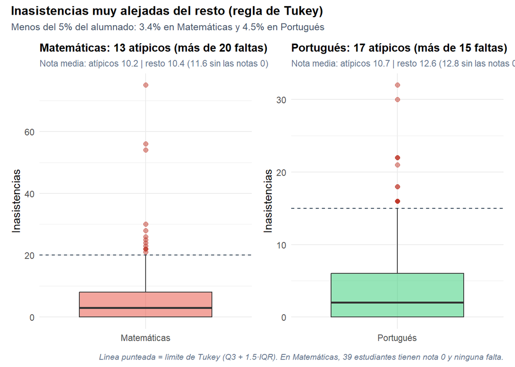

Figura 4. Inasistencias atípicas según la regla de Tukey (IQR)

Tabla 5. Inasistencias atípicas y notas de ese grupo

| Asignatura | Límite de Tukey (faltas) | Atípicos (%) | Máximo | Asimetría | Nota media atípicos | Nota media resto | Diferencia (IC 95%) |
| --- | --- | --- | --- | --- | --- | --- | --- |
| Matemáticas | 20 | 13 (3.4%) | 75 | 4.01 | 10.23 | 10.39 | -0.16 [-2.68; 2.35] |
| Portugués | 15 | 17 (4.5%) | 32 | 2.17 | 10.71 | 12.60 | -1.89 [-3.40; -0.38] |

**Interpretación:**

- **Pocos casos:** con el límite de Tukey (línea punteada) hay **13 atípicos en Matemáticas** (más de 20 faltas) y **17 en Portugués** (más de 15): menos del 5% del alumnado. El coeficiente de asimetría (4.01 en Matemáticas, 2.17 en Portugués) confirma una cola derecha pronunciada: la media de faltas está inflada por un pequeño grupo, no por un comportamiento generalizado.
- **Portugués:** los estudiantes con faltas atípicas tienen una nota promedio 1.89 puntos menor que el resto (IC 95%: -3.40 a -0.38). Es una asociación, no una prueba de que las faltas causen la nota.
- **Matemáticas:** la diferencia de promedios es de solo 0.16 puntos, pero con 13 casos el intervalo (IC 95%: -2.68 a 2.35) es demasiado amplio para concluir que “no hay diferencia”. Además, los 39 estudiantes con nota 0 y ninguna falta bajan el promedio del grupo restante: sin ellos, el resto promedia 11.62 frente a 10.23 de los atípicos (y las medianas son 11 y 9). La comparación depende de cómo se traten esos ceros.

# 6 Conclusiones

Retomando la pregunta de investigación —¿cómo se relacionan el alcohol y la zona de residencia con las notas y las inasistencias, y qué tan variable es ese comportamiento entre géneros?—, el análisis descriptivo permite responder:

1. **Alcohol y notas:** el consumo de alcohol los fines de semana se asocia con notas algo más bajas en Portugués (*r* = -0.23) y casi no se asocia con las de Matemáticas (*r* = -0.03). Hay estudiantes con consumo alto y notas altas, así que el alcohol por sí solo dice poco sobre la nota de una persona.
2. **Diferencias entre géneros:** en Portugués el patrón cambia según el sexo: el promedio de los hombres baja al pasar de consumo bajo a moderado y luego se mantiene, mientras el de las mujeres se mantiene cerca de 13. En Matemáticas los hombres también bajan, pero las mujeres no siguen un patrón claro.
3. **Zona de residencia:** los estudiantes rurales promedian menos que los urbanos; la diferencia es clara en Portugués e incierta en Matemáticas, y las notas de ambas zonas se solapan mucho. Viajar 30 minutos o más es mucho más frecuente en zona rural, lo que puede ser una barrera de acceso.
4. **Inasistencias:** un grupo reducido de estudiantes (13 en Matemáticas y 17 en Portugués) concentra las faltas extremas. En Portugués sus notas son en promedio más bajas; en Matemáticas la comparación es incierta y está afectada por los ceros.

**Limitaciones y cuidados.** Los datos permiten hablar de asociaciones, no de causas. El cruce de asignaturas es por perfil, no por identificador único. Varios grupos son pequeños (por ejemplo, las mujeres con consumo alto) y hay estudiantes con nota 0 que afectan las medias. `traveltime` es un código ordinal, no un tiempo exacto.

Si se construye un modelo predictivo de deserción o bajo rendimiento, `address`, `traveltime` y una bandera de ausentismo atípico (basada en la regla IQR aquí definida) pueden ser variables útiles para orientar apoyos, pero deben usarse con cuidado para no etiquetar ni estigmatizar a estudiantes por su zona de residencia. Este análisis descriptivo complementa —no reemplaza— ese tipo de modelo.

# 7 Referencias

P. Cortez and A. Silva. *Using Data Mining to Predict Secondary School Student Performance*. In A. Brito and J. Teixeira (eds.), Proceedings of 5th FUBUTEC Conference, pp. 5–12, Porto, Portugal, 2008, EUROSIS. Dataset disponible públicamente como *Student Performance Data Set*, UCI Machine Learning Repository.